# TS_AS2

Zhilin Yang

2023-07-04

## Question 1

Load the visitors.rda dataset, make a time plot of your data and describe the main features of the series.

```r
load(file = 'C:/Users/Richa/Desktop/TS/week2/visitors.rda')
head(visitors)
```

```
##   Quarter Origin Arrivals
## 1    4018     US    32316
## 2    4108     US    23721
## 3    4199     US    24533
## 4    4291     US    33438
## 5    4383     US    33527
## 6    4473     US    28366
```

```r
df_quarter <- ts(visitors[['Arrivals']], start = c(1981, 1), frequency = 4)
head(df_quarter)
```

```
## [1] 32316 23721 24533 33438 33527 28366
```

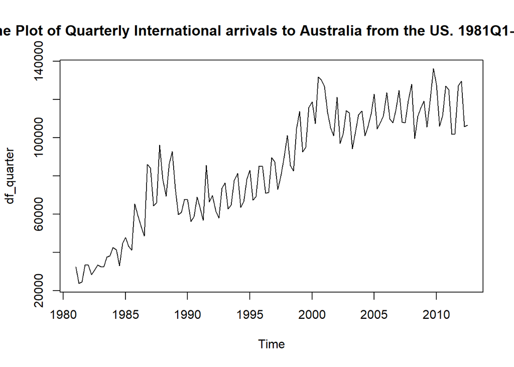

```r
plot(df_quarter, main = 'Time Plot of Quarterly International arrivals to Australia from the US. 1981Q1-2012Q3')
```

The main features in this dataset are the Quarter and Arrivals. In addition, we can see that the dataset has a seasonality with an upward trend

## Question 2

What is the appropriate Holt-Winters method for this data set (multiplicative / additive)? why?

As we can see from the plot in Question1, the sesonal variations are not constant through the series. In addition, the amplitude of the seasonal pattern is proportional to the average level within the season.

Therefore, the appropriate Holt-Winters method for this data set should be the multiplicative method.

## Question 3

Use the hw() function to forecast the next 20 quarters using Holt-Winters’ methods. Experiment with the following methods • Linear trend with additive seasonality • Linear trend with multiplicative seasonality • Linear trend with additive seasonality and damping • Linear trend with multiplicative seasonality and damping

```r
library(forecast)
```

• Linear trend with additive seasonality

```r
LT_Add = hw(df_quarter, seasonal = 'additive', h = 20)
summary(LT_Add)
```

```
##
## Forecast method: Holt-Winters' additive method
##
## Model Information:
## Holt-Winters' additive method
##
## Call:
##  hw(y = df_quarter, h = 20, seasonal = "additive")
##
##   Smoothing parameters:
##     alpha = 0.4857
##     beta  = 1e-04
##     gamma = 1e-04
##
##   Initial states:
##     l = 29200.6271
##     b = 690.908
##     s = 6037.329 -4695.766 -7931.984 6590.422
##
##   sigma:  7792.067
##
##      AIC     AICc      BIC
## 2901.007 2902.546 2926.605
##
## Error measures:
##                     ME     RMSE      MAE        MPE     MAPE      MASE
## Training set -41.56992 7542.656 5478.829 -0.3174557 7.439141 0.7423397
##                    ACF1
## Training set 0.02191009
##
## Forecasts:
##         Point Forecast     Lo 80    Hi 80     Lo 95    Hi 95
## 2012 Q4       121407.0 111421.09 131393.0 106134.85 136679.2
## 2013 Q1       122651.1 111548.98 133753.2 105671.88 139630.3
## 2013 Q2       108818.3  96702.04 120934.6  90288.07 127348.6
## 2013 Q3       112744.7  99692.48 125797.0  92783.02 132706.5
## 2013 Q4       124168.5 110242.36 138094.7 102870.29 145466.8
## 2014 Q1       125412.6 110664.21 140161.0 102856.89 147968.3
## 2014 Q2       111579.8  96052.40 127107.3  87832.67 135327.0
## 2014 Q3       115506.3  99236.73 131775.8  90624.16 140388.4
## 2014 Q4       126930.1 109950.27 143909.8 100961.71 152898.4
## 2015 Q1       128174.1 110512.62 145835.6 101163.18 155185.1
## 2015 Q2       114341.4  96023.23 132659.5  86326.19 142356.5
## 2015 Q3       118267.8  99315.49 137220.1  89282.76 147252.8
## 2015 Q4       129691.6 110125.18 149258.0  99767.36 159615.8
## 2016 Q1       130935.6 110773.85 151097.4 100100.84 161770.5
## 2016 Q2       117102.9  96362.53 137843.2  85383.25 148822.5
## 2016 Q3       121029.3  99725.87 142332.7  88448.51 153610.1
## 2016 Q4       132453.1 110600.64 154305.5  99032.66 165873.5
## 2017 Q1       133697.2 111309.16 156085.2  99457.66 167936.7
## 2017 Q2       119864.4  96953.14 142775.7  84824.65 154904.2
## 2017 Q3       123790.8 100367.78 147213.9  87968.37 159613.3
```

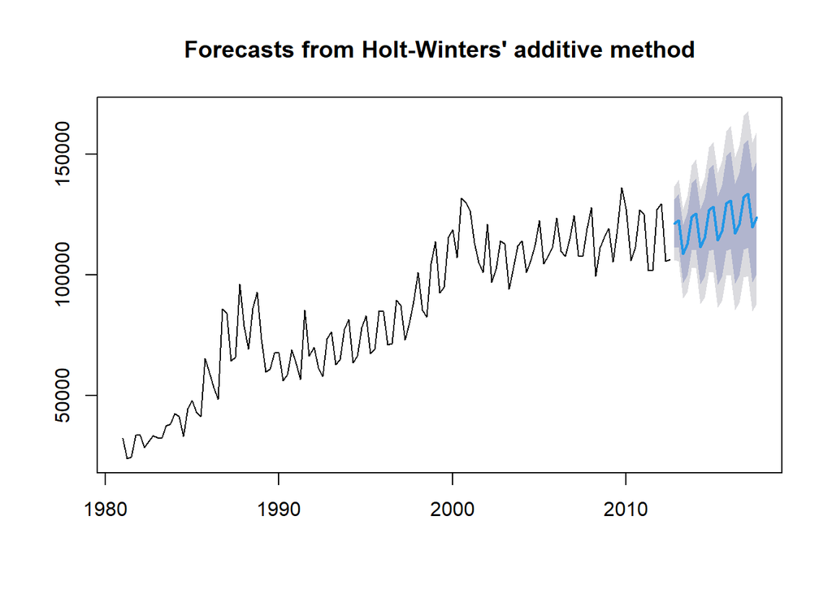

```r
plot(LT_Add)
```

• Linear trend with multiplicative seasonality

```r
LT_Multi = hw(df_quarter, seasonal = 'multiplicative', h = 20)
summary(LT_Multi)
```

```
##
## Forecast method: Holt-Winters' multiplicative method
##
## Model Information:
## Holt-Winters' multiplicative method
##
## Call:
##  hw(y = df_quarter, h = 20, seasonal = "multiplicative")
##
##   Smoothing parameters:
##     alpha = 0.4435
##     beta  = 0.0088
##     gamma = 1e-04
##
##   Initial states:
##     l = 28878.5208
##     b = 1383.0434
##     s = 1.0663 0.9466 0.9086 1.0785
##
##   sigma:  0.1018
##
##      AIC     AICc      BIC
## 2910.775 2912.314 2936.373
##
## Error measures:
##                     ME     RMSE      MAE       MPE     MAPE      MASE
## Training set -774.8691 7550.956 5444.033 -1.701107 6.947776 0.7376251
##                    ACF1
## Training set 0.08109975
##
## Forecasts:
##         Point Forecast     Lo 80    Hi 80    Lo 95    Hi 95
## 2012 Q4       123862.7 107696.49 140028.9 99138.61 148586.8
## 2013 Q1       125806.2 107782.01 143830.4 98240.58 153371.8
## 2013 Q2       106438.3  89903.90 122972.6 81151.14 131725.4
## 2013 Q3       111359.4  92774.92 129943.8 82936.91 139781.8
## 2013 Q4       125986.0 103558.59 148413.3 91686.26 160285.6
## 2014 Q1       127953.5 103796.71 152110.4 91008.85 164898.2
## 2014 Q2       108247.3  86674.94 129819.7 75255.21 141239.4
## 2014 Q3       113244.0  89514.57 136973.5 76952.95 149535.1
## 2014 Q4       128109.2  99976.57 156241.8 85084.06 171134.3
## 2015 Q1       130100.9 100245.72 159956.1 84441.34 175760.4
## 2015 Q2       110056.4  83730.22 136382.5 69794.01 150318.7
## 2015 Q3       115128.7  86484.09 143773.4 71320.54 158936.9
## 2015 Q4       130232.4  96594.01 163870.9 78786.90 181678.0
## 2016 Q1       132248.3  96847.61 167648.9 78107.65 186388.9
## 2016 Q2       111865.4  80880.40 142850.4 64477.93 159252.9
## 2016 Q3       117013.4  83522.95 150503.9 65794.18 168232.6
## 2016 Q4       132355.7  93261.45 171449.9 72566.20 192145.2
## 2017 Q1       134395.6  93475.82 175315.4 71814.19 196977.0
## 2017 Q2       113674.5  78035.14 149313.8 59168.81 168180.1
## 2017 Q3       118898.1  80550.63 157245.6 60250.70 177545.5
```

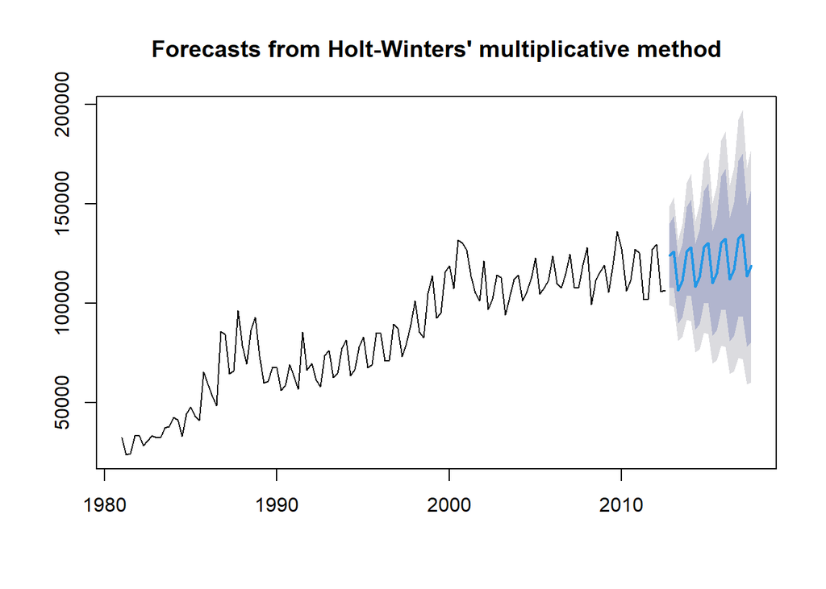

```r
plot(LT_Multi)
```

• Linear trend with additive seasonality and damping

```r
LT_Add_Damping= hw(df_quarter, seasonal = 'additive', h = 20, damped = TRUE)
summary(LT_Add_Damping)
```

```
##
## Forecast method: Damped Holt-Winters' additive method
##
## Model Information:
## Damped Holt-Winters' additive method
##
## Call:
##  hw(y = df_quarter, h = 20, seasonal = "additive", damped = TRUE)
##
##   Smoothing parameters:
##     alpha = 0.4702
##     beta  = 1e-04
##     gamma = 0.0761
##     phi   = 0.98
##
##   Initial states:
##     l = 26752.4056
##     b = 1912.2775
##     s = 5901.9 -4718.818 -7842.813 6659.731
##
##   sigma:  7834.775
##
##      AIC     AICc      BIC
## 2903.324 2905.221 2931.766
##
## Error measures:
##                    ME     RMSE      MAE        MPE     MAPE     MASE       ACF1
## Training set 18.41066 7552.064 5551.979 -0.8327106 7.471211 0.752251 0.03207652
##
## Forecasts:
##         Point Forecast     Lo 80    Hi 80     Lo 95    Hi 95
## 2012 Q4       121033.7 110993.04 131074.4 105677.84 136389.6
## 2013 Q1       123116.0 112020.39 134211.7 106146.71 140085.4
## 2013 Q2       105058.3  92999.21 117117.4  86615.52 123501.0
## 2013 Q3       109824.8  96873.38 122776.1  90017.34 129632.2
## 2013 Q4       121581.7 107515.11 135648.4 100068.68 143094.8
## 2014 Q1       123653.1 108813.84 138492.4 100958.40 146347.8
## 2014 Q2       105584.6  90010.70 121158.5  81766.38 129402.8
## 2014 Q3       110340.5  94064.89 126616.2  85449.08 135232.0
## 2014 Q4       122087.2 104909.68 139264.8  95816.44 148358.0
## 2015 Q1       124148.5 106331.79 141965.2  96900.21 151396.8
## 2015 Q2       106070.1  87636.16 124504.0  77877.84 134262.3
## 2015 Q3       110816.3  91784.99 129847.6  81710.42 139922.2
## 2015 Q4       122553.5 102744.43 142362.5  92258.17 152848.7
## 2016 Q1       124605.4 104238.90 144971.9  93457.53 155753.3
## 2016 Q2       106517.8  85608.56 127427.1  74539.86 138495.8
## 2016 Q3       111255.1  89816.63 132693.6  78467.78 144042.5
## 2016 Q4       122983.5 100850.98 145116.0  89134.73 156832.3
## 2017 Q1       125026.8 102393.39 147660.3  90411.97 159641.7
## 2017 Q2       106930.9  83807.18 130054.5  71566.25 142295.5
## 2017 Q3       111659.9  88056.02 135263.7  75560.90 147758.8
```

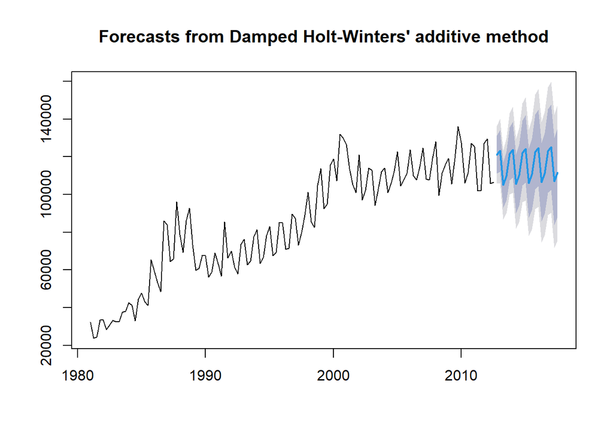

```r
plot(LT_Add_Damping)
```

• Linear trend with multiplicative seasonality and damping

```r
LT_Multi_Damping= hw(df_quarter, seasonal = 'multiplicative', h = 20, damped = TRUE)
summary(LT_Multi_Damping)
```

```
##
## Forecast method: Damped Holt-Winters' multiplicative method
##
## Model Information:
## Damped Holt-Winters' multiplicative method
##
## Call:
##  hw(y = df_quarter, h = 20, seasonal = "multiplicative", damped = TRUE)
##
##   Smoothing parameters:
##     alpha = 0.52
##     beta  = 0.0027
##     gamma = 1e-04
##     phi   = 0.98
##
##   Initial states:
##     l = 26914.2591
##     b = 2002.8599
##     s = 1.0638 0.9467 0.9133 1.0762
##
##   sigma:  0.1034
##
##      AIC     AICc      BIC
## 2913.642 2915.538 2942.084
##
## Error measures:
##                     ME     RMSE     MAE        MPE     MAPE      MASE
## Training set -1.834419 7460.002 5363.22 -0.9701216 6.852661 0.7266756
##                      ACF1
## Training set -0.001971966
##
## Forecasts:
##         Point Forecast     Lo 80    Hi 80    Lo 95    Hi 95
## 2012 Q4       122225.2 106033.32 138417.1 97461.86 146988.5
## 2013 Q1       123798.8 105276.90 142320.8 95471.97 152125.7
## 2013 Q2       105187.4  87816.96 122557.8 78621.62 131753.1
## 2013 Q3       109171.5  89578.75 128764.3 79206.97 139136.1
## 2013 Q4       122829.1  99138.55 146519.6 86597.54 159060.7
## 2014 Q1       124397.5  98830.37 149964.7 85295.93 163499.2
## 2014 Q2       105685.3  82691.88 128678.6 70519.92 140850.6
## 2014 Q3       109677.3  84552.31 134802.3 71251.94 148102.7
## 2014 Q4       123386.1  93754.23 153018.0 78068.05 168704.2
## 2015 Q1       124949.8  93607.44 156292.1 77015.81 172883.7
## 2015 Q2       106144.5  78421.35 133867.7 63745.60 148543.4
## 2015 Q3       110143.9  80270.02 140017.7 64455.77 155832.0
## 2015 Q4       123899.9  89083.75 158716.1 70653.18 177146.7
## 2016 Q1       125459.1  89009.06 161909.2 69713.57 181204.7
## 2016 Q2       106568.1  74614.21 138522.0 57698.83 155437.4
## 2016 Q3       110574.2  76411.57 144736.8 58326.96 162821.4
## 2016 Q4       124373.9  84836.81 163910.9 63907.17 184840.6
## 2017 Q1       125929.0  84794.32 167063.6 63018.96 188838.9
## 2017 Q2       106958.8  71100.32 142817.3 52117.97 161799.7
## 2017 Q3       110971.1  72828.41 149113.8 52636.88 169305.4
```

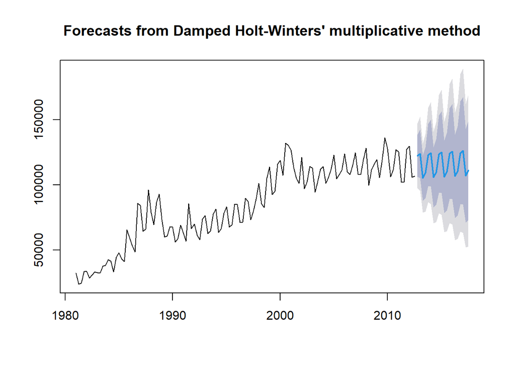

```r
plot(LT_Multi_Damping)
```

## Question 4

Use the accuracy() function to compare the Root-Mean-Square-Error (RMSE) values of the forecasts from the various methods. Which do you prefer and why?

```r
rmse_LT_Add <- accuracy(LT_Add)[2]
rmse_LT_Multi <- accuracy(LT_Multi)[2]
rmse_LT_Add_Damping <- accuracy(LT_Add_Damping)[2]
rmse_LT_Multi_Damping <- accuracy(LT_Multi_Damping)[2]
cat("The RMSE of Linear trend with additive seasonality is", rmse_LT_Add,"\n")
```

```
## The RMSE of Linear trend with additive seasonality is 7542.656
```

```r
cat("The RMSE of Linear trend with additive seasonality is", rmse_LT_Multi, "\n")
```

[output not shown]

```r
cat("The RMSE of Linear trend with additive seasonality and damping is", rmse_LT_Add_Damping, "\n")
```

```
## The RMSE of Linear trend with additive seasonality and damping is 7552.064
```

```r
cat("The RMSE of Linear trend with multiplicative seasonality and damping is", rmse_LT_Multi_Damping, "\n")
```

```
## The RMSE of Linear trend with multiplicative seasonality and damping is 7460.002
```

From the above result, we can see that the Linear trend with multiplicative seasonality and damping method has the lowest RMSE. Therefore, it is preferred to choose this method.

## Question 5

Use the checkresiduals() function to check that the residuals from the best model look like white noise and provide a summary of the model’s smoothing parameters using the summary() function.

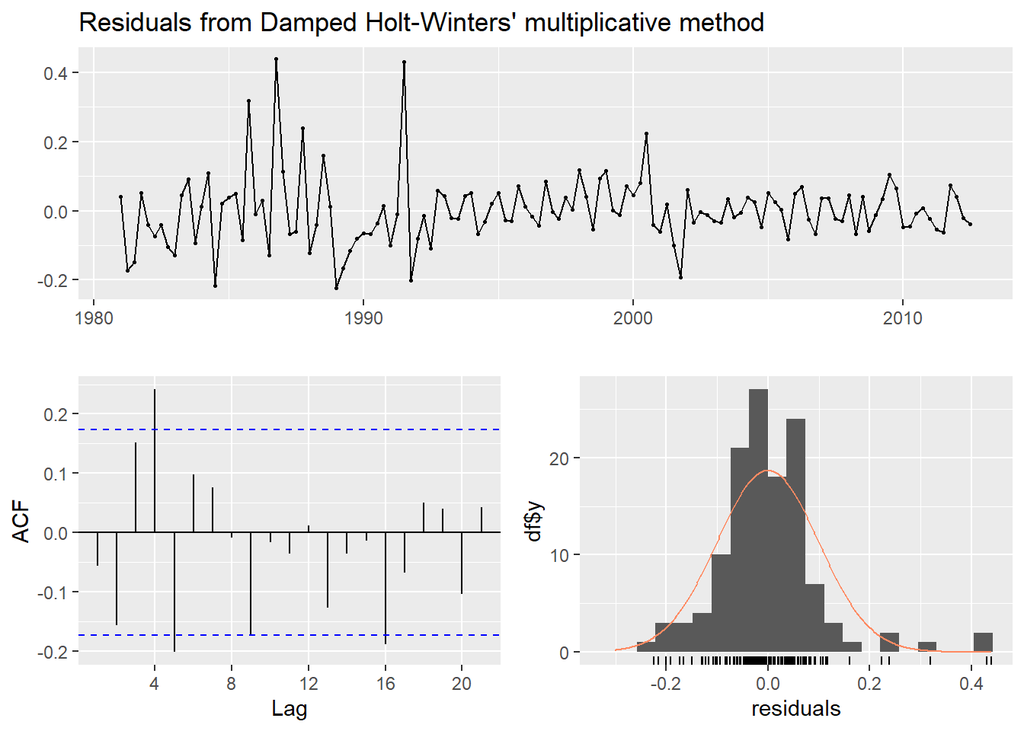

```
##
##  Ljung-Box test
##
## data:  Residuals from Damped Holt-Winters' multiplicative method
## Q* = 26.266, df = 3, p-value = 8.388e-06
##
## Model df: 9.   Total lags used: 12
```

```r
checkresiduals(LT_Multi_Damping)
```

```r
summary(LT_Multi_Damping)
```

```
##
## Forecast method: Damped Holt-Winters' multiplicative method
##
## Model Information:
## Damped Holt-Winters' multiplicative method
##
## Call:
##  hw(y = df_quarter, h = 20, seasonal = "multiplicative", damped = TRUE)
##
##   Smoothing parameters:
##     alpha = 0.52
##     beta  = 0.0027
##     gamma = 1e-04
##     phi   = 0.98
##
##   Initial states:
##     l = 26914.2591
##     b = 2002.8599
##     s = 1.0638 0.9467 0.9133 1.0762
##
##   sigma:  0.1034
##
##      AIC     AICc      BIC
## 2913.642 2915.538 2942.084
##
## Error measures:
##                     ME     RMSE     MAE        MPE     MAPE      MASE
## Training set -1.834419 7460.002 5363.22 -0.9701216 6.852661 0.7266756
##                      ACF1
## Training set -0.001971966
##
## Forecasts:
##         Point Forecast     Lo 80    Hi 80    Lo 95    Hi 95
## 2012 Q4       122225.2 106033.32 138417.1 97461.86 146988.5
## 2013 Q1       123798.8 105276.90 142320.8 95471.97 152125.7
## 2013 Q2       105187.4  87816.96 122557.8 78621.62 131753.1
## 2013 Q3       109171.5  89578.75 128764.3 79206.97 139136.1
## 2013 Q4       122829.1  99138.55 146519.6 86597.54 159060.7
## 2014 Q1       124397.5  98830.37 149964.7 85295.93 163499.2
## 2014 Q2       105685.3  82691.88 128678.6 70519.92 140850.6
## 2014 Q3       109677.3  84552.31 134802.3 71251.94 148102.7
## 2014 Q4       123386.1  93754.23 153018.0 78068.05 168704.2
## 2015 Q1       124949.8  93607.44 156292.1 77015.81 172883.7
## 2015 Q2       106144.5  78421.35 133867.7 63745.60 148543.4
## 2015 Q3       110143.9  80270.02 140017.7 64455.77 155832.0
## 2015 Q4       123899.9  89083.75 158716.1 70653.18 177146.7
## 2016 Q1       125459.1  89009.06 161909.2 69713.57 181204.7
## 2016 Q2       106568.1  74614.21 138522.0 57698.83 155437.4
## 2016 Q3       110574.2  76411.57 144736.8 58326.96 162821.4
## 2016 Q4       124373.9  84836.81 163910.9 63907.17 184840.6
## 2017 Q1       125929.0  84794.32 167063.6 63018.96 188838.9
## 2017 Q2       106958.8  71100.32 142817.3 52117.97 161799.7
## 2017 Q3       110971.1  72828.41 149113.8 52636.88 169305.4
```

From the residul plot, we can see the residuals do not look like white noise as they are not vibrating around 0 at some points.

From the Ljung-Box test, p-value = 8.388e-06 which is smaller than 0.05. Therefore, we reject the null hypothesis. There is significant autocorrelation existed. The residuals should not be white noise.

From the summary table, we can see that：

Smoothing parameters: alpha = 0.52(level of model) beta = 0.0027 (increasing trend with a low slope) gamma = 1e-04 (seasonal component) phi = 0.98 (degree of damping)

## Question 6

Use the snaive() function to forecast the next 20 quarters, and the accuracy() function to evaluate the model. Did your best model beat the seasonal naïve approach?

```r
forcast_snaive = snaive(df_quarter, h=20)
RMSE_snaive = accuracy(forcast_snaive)[2]
cat("The RMSE of Linear trend with additive seasonality and damping is", RMSE_snaive)
```

[output not shown]

Recall that my best model is the Linear trend with multiplicative seasonality and damping which has RMSE 7460<10298. Therefore, my best model eat the seasonal naive approach.